# Protein Structural Comparisons

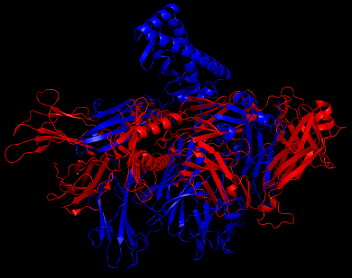

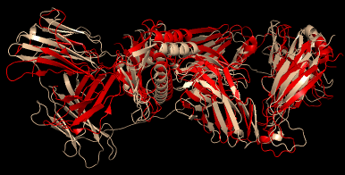

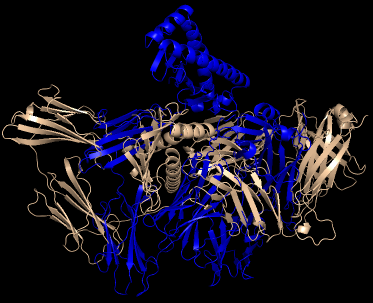

Alignments for HLA class I histocompatibility antigen, A alpha chain (PDB 6EQB).

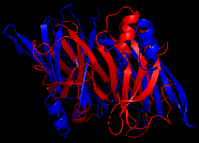

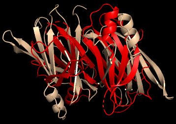

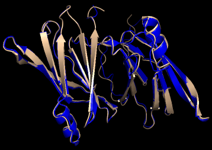

Alignments for Transthyretin (PDB 4MRB).

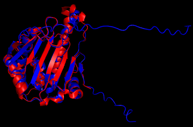

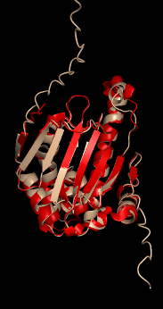

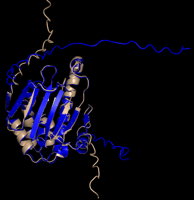

Alignments for Heat shock protein HSP 90‐alpha N-terminal (PDB 6GQ6).

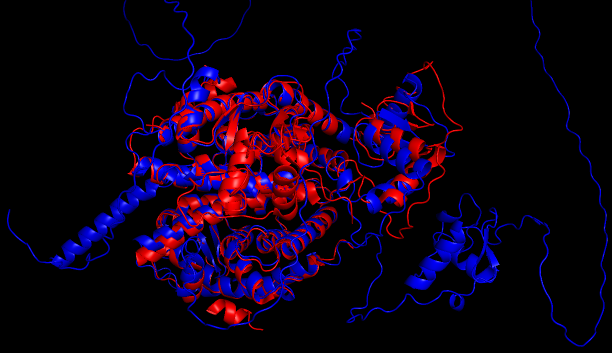

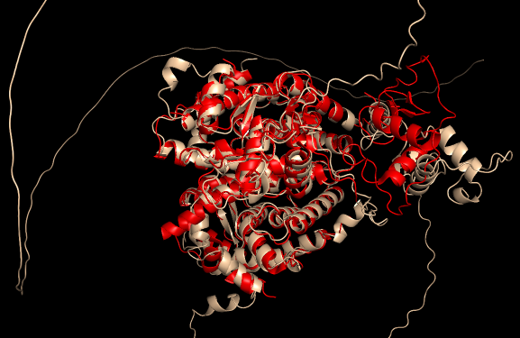

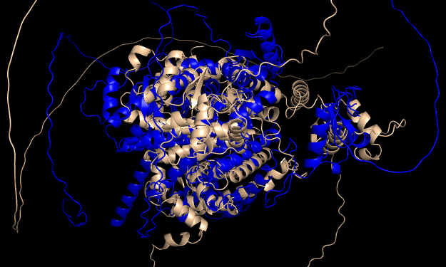

Alignments for Nuclear receptor coactivator 2 (PDB 3DZU).

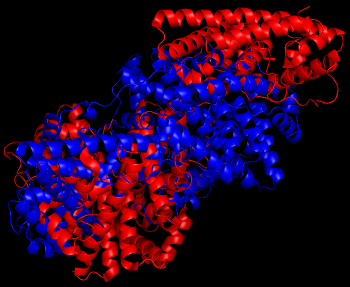

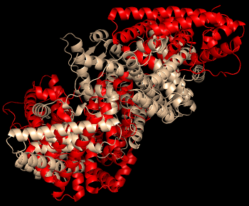

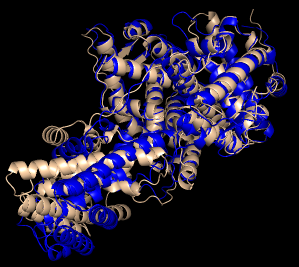

Alignments for Estrogen receptor (PDB 1QKU).

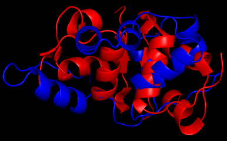

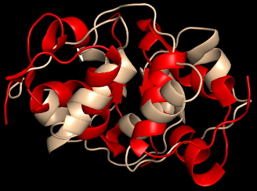

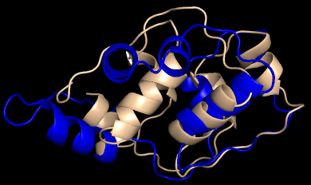

Alignments for Insulin (PDB 4F1A).

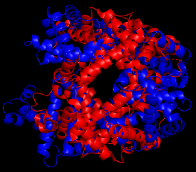

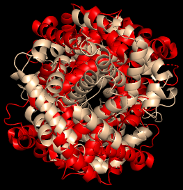

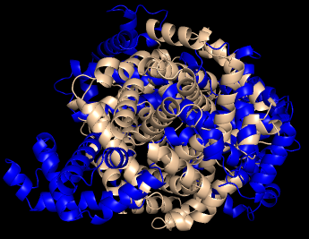

Alignments for Hemoglobin (PDB 4HHB).

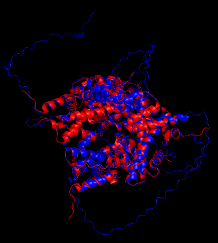

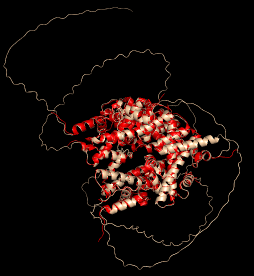

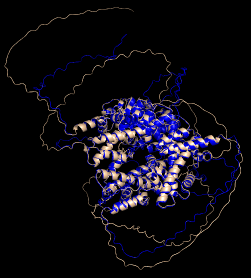

Alignments for Nucleosome containing H3.1 (PDB 5B1M).

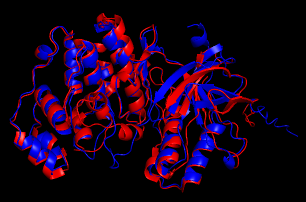

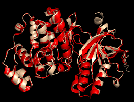

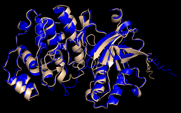

Alignments for Mitogen‐activated protein kinase 14 (PDB 5ETI).

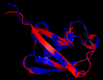

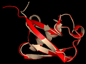

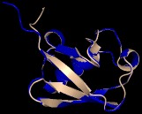

Alignments for Ubiquitin (PDB 1UBQ).

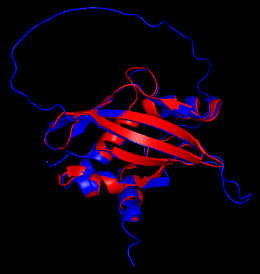

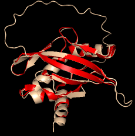

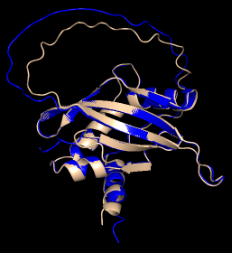

Alignments for Nuclear receptor coactivator 1 (PDB 5NWX).

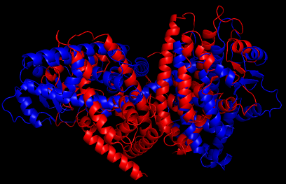

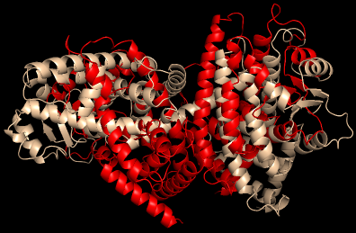

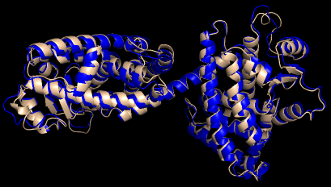

Alignments for Peroxisome proliferator‐activated receptor gamma (PDB 1PRG).

# Plots

After all of the alignments were completed, I made several plots to explore the relationships between the variables I selected.

## Amino Acid Sequence Length per Protein

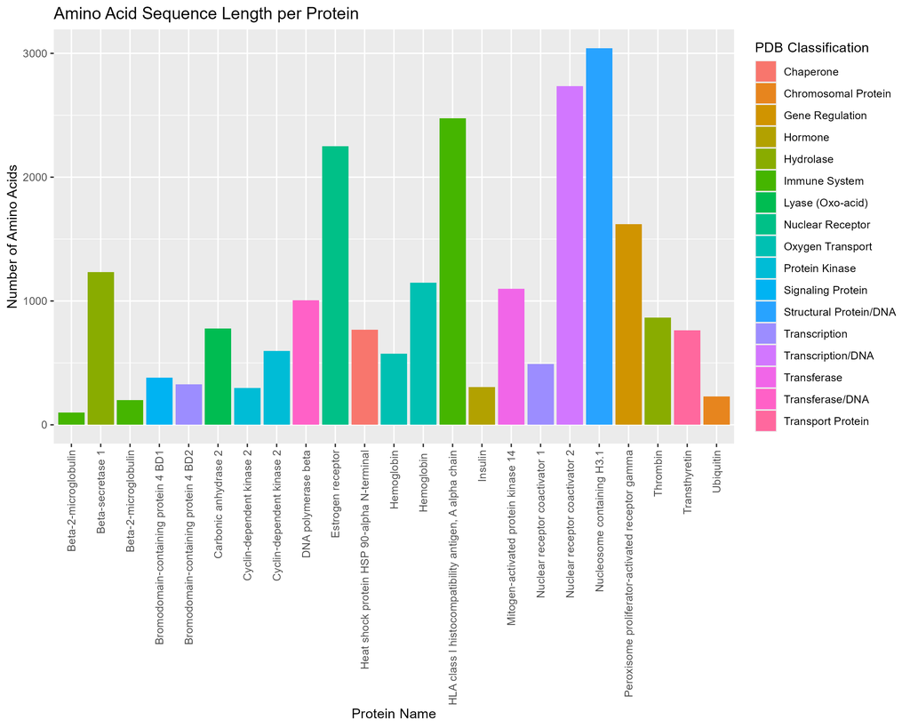

```r
plot_type_aa <- protein_df %>%
  ggplot(aes(x = Protein_Name,
             y = Number_of_AA,
             fill = PDB_Class)) +
  geom_bar(stat = 'identity') +
  labs(x = "Protein Name",
       y = "Number of Amino Acids",
       title = "Amino Acid Sequence Length per Protein",
       fill = "PDB Classification") +
  theme(axis.text.x = element_text(angle = 90, vjust = 0.5, hjust = 1))
ggsave('Plots/type_aa.png', plot = plot_type_aa,
       dpi = 300, height = 8, width = 10)
```

## X-Ray Diffraction Resolution vs Amino Acid Sequence Length

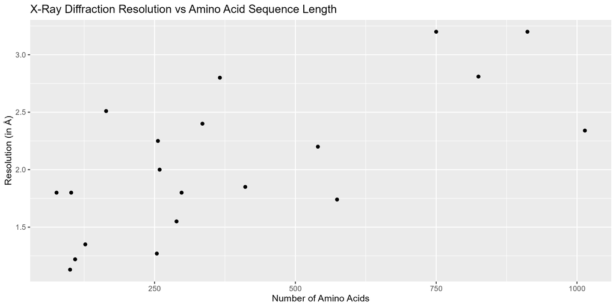

```r
plot_aa_xray <- protein_df %>%
  filter(!is.na(Resolution)) %>%
  ggplot(aes(x = Number_of_AA,
             y = Resolution)) +
  geom_point() +
  labs(x = "Number of Amino Acids",
       y = "Resolution (in Å)",
       title = "X-Ray Diffraction Resolution vs Amino Acid Sequence Length")
ggsave('Plots/aa_xray.png', plot = plot_aa_xray,
       dpi = 300, height = 5, width = 10)
```

## RMSD When Aligned With AlphaFold 2 vs Amino Acid Sequence Length

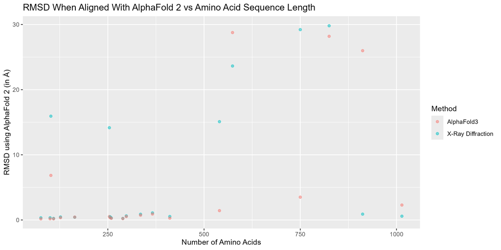

```r
plot_aa_rmsd2 <- protein_df %>%
  filter(!is.na(RMSD_2)) %>%
  ggplot(aes(x = Number_of_AA,
             y = RMSD_2,
             color = Method)) +
  geom_point(alpha = 0.5) +
  labs(x = "Number of Amino Acids",
       y = "RMSD using AlphaFold 2 (in Å)",
       title = "RMSD When Aligned With AlphaFold 2 vs Amino Acid Sequence Length")
ggsave('Plots/aa_rmsd2.png', plot = plot_aa_rmsd2,
       dpi = 300, height = 5, width = 10)
```

## RMSD When Aligned with AlphaFold 3 vs Amino Acid Sequence Length

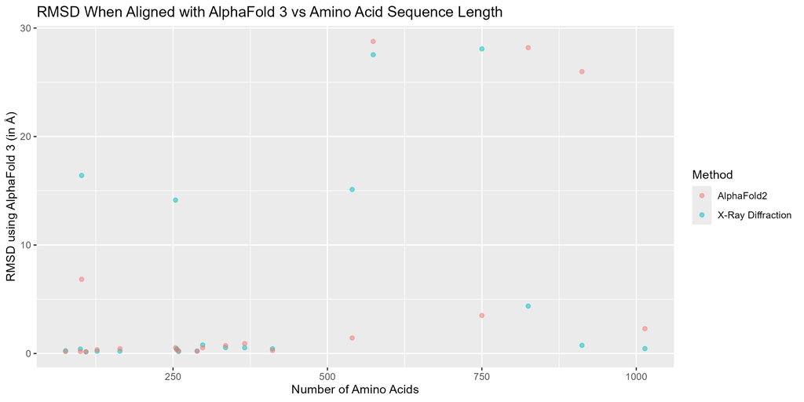

```r
plot_aa_rmsd3 <- protein_df %>%
  filter(!is.na(RMSD_3)) %>%
  ggplot(aes(x = Number_of_AA,
             y = RMSD_3,
             color = Method)) +
  geom_point(alpha = 0.5) +
  labs(x = "Number of Amino Acids",
       y = "RMSD using AlphaFold 3 (in Å)",
       title = "RMSD When Aligned with AlphaFold 3 vs Amino Acid Sequence Length")
ggsave('Plots/aa_rmsd3.png', plot = plot_aa_rmsd3,
       dpi = 300, height = 5, width = 10)
```

## RMSD When Aligned with AlphaFold 2 vs pTM from Highest Rank

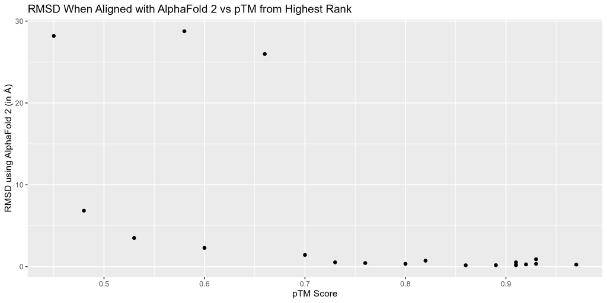

```r
plot_ptm_rmsd2 <- protein_df %>%
  filter(!is.na(highest_pTM) & !is.na(RMSD_2)) %>%
  ggplot(aes(x = highest_pTM,
             y = RMSD_2)) +
  geom_point() +
  labs(x = "pTM Score",
       y = "RMSD using AlphaFold 2 (in Å)",
       title = "RMSD When Aligned with AlphaFold 2 vs pTM from Highest Rank")
ggsave('Plots/ptm_rmsd2.png', plot = plot_ptm_rmsd2,
       dpi = 300, height = 5, width = 10)
```

## RMSD When Aligned with AlphaFold 3 vs pTM from Highest Rank

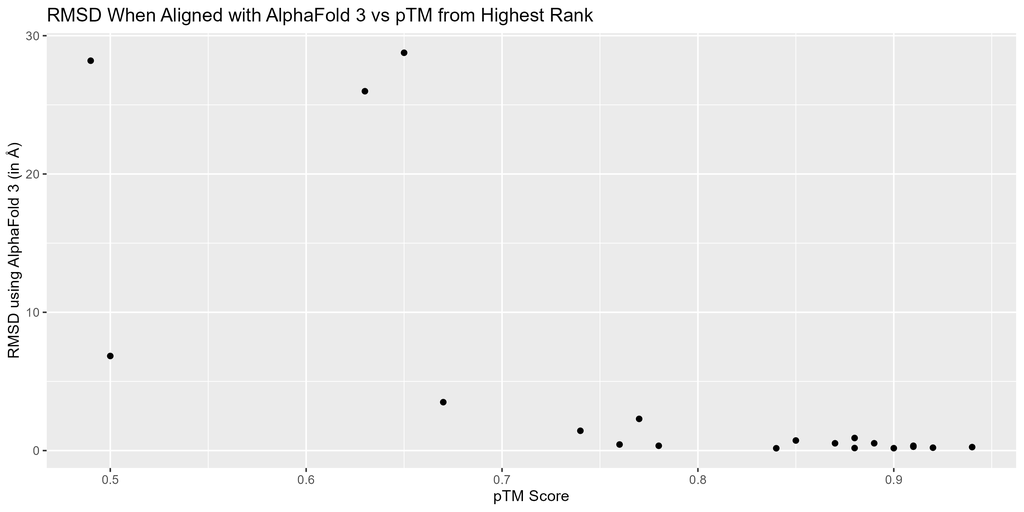

```r
plot_ptm_rmsd3 <- protein_df %>%
  filter(!is.na(highest_pTM) & !is.na(RMSD_3)) %>%
  ggplot(aes(x = highest_pTM,
             y = RMSD_3)) +
  geom_point() +
  labs(x = "pTM Score",
       y = "RMSD using AlphaFold 3 (in Å)",
       title = "RMSD When Aligned with AlphaFold 3 vs pTM from Highest Rank")
ggsave('Plots/ptm_rmsd3.png', plot = plot_ptm_rmsd3,
       dpi = 300, height = 5, width = 10)
```

## Amino Acid Sequence Length vs pTM from Highest Rank

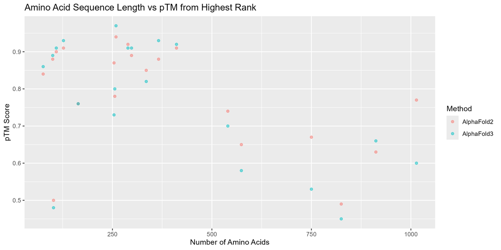

```r
plot_aa_ptm <- protein_df %>%
  filter(!is.na(highest_pTM)) %>%
  ggplot(aes(x = Number_of_AA,
             y = highest_pTM,
             color = Method)) +
  geom_point(alpha = 0.5) +
  labs(x = "Number of Amino Acids",
       y = "pTM Score",
       title = "Amino Acid Sequence Length vs pTM from Highest Rank")
ggsave('Plots/aa_ptm.png', plot = plot_aa_ptm,
       dpi = 300, height = 5, width = 10)
```

## RMSD When Aligned with AlphaFold 2 vs Resolution of X-Ray Diffraction

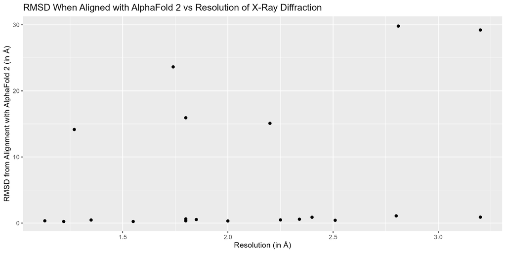

```r
plot_xray_rmsd2 <- protein_df %>%
  filter(!is.na(Resolution) & !is.na(RMSD_2)) %>%
  ggplot(aes(x = Resolution,
             y = RMSD_2)) +
  geom_point() +
  labs(x = "Resolution (in Å)",
       y = "RMSD from Alignment with AlphaFold 2 (in Å)",
       title = "RMSD When Aligned with AlphaFold 2 vs Resolution of X-Ray Diffraction")
ggsave('Plots/xray_rmsd2.png', plot = plot_xray_rmsd2,
       dpi = 300, height = 5, width = 10)
```

## RMSD When Aligned with AlphaFold 3 vs Resolution of X-Ray Diffraction

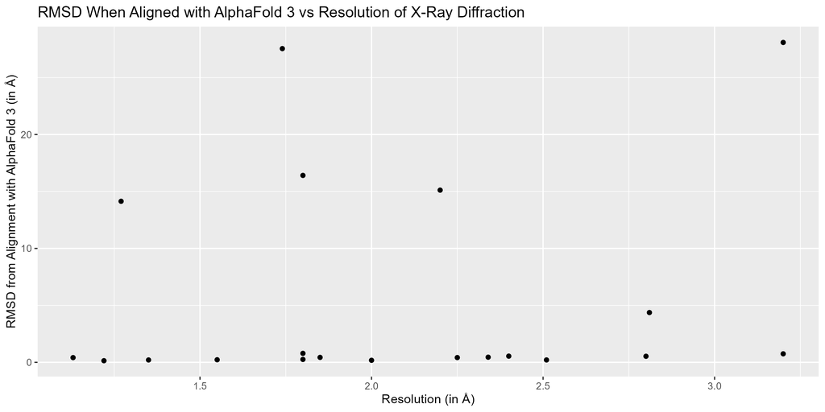

```r
plot_xray_rmsd3 <- protein_df %>%
  filter(!is.na(Resolution) & !is.na(RMSD_3)) %>%
  ggplot(aes(x = Resolution,
             y = RMSD_3)) +
  geom_point() +
  labs(x = "Resolution (in Å)",
       y = "RMSD from Alignment with AlphaFold 3 (in Å)",
       title = "RMSD When Aligned with AlphaFold 3 vs Resolution of X-Ray Diffraction")
ggsave('Plots/xray_rmsd3.png', plot = plot_xray_rmsd3,
       dpi = 300, height = 5, width = 10)
```

# Statistical Analysis

## Load Packages

```r
library(easystats)
library(skimr)
library(MASS)
```

## Linear Models

To begin my statistical analysis, I made a linear model for each plot (except the protein type and sequence length plot). My goal with these models was to figure out which characteristics and relationships were the most/least significant.

Once I compared the performance of all the basic linear models, I used the MASS package to find the best models for RMSD values. Then compared those two additional models to the other ones I had made. In the comparison plots, models that cover a larger area of the plot are believed to be better than those that cover a smaller area. Additionally, when finding the best models, it is important to note that the “+” in the formula means considering both characteristics, while the “*” means considering both characteristics and their interactions.

The direct outputs for the code in this section can be difficult to read. In an effort to maintain transparency and simplicity, I decided to keep the coding chunks visible and display the most pertinent sections of output below them. Linear models follow the y = mx + b format, so the “Estimate” column gives the b and m values, respectively.

### X-Ray Diffraction Resolution vs Amino Acid Sequence Length

```r
mod_aa_xray <- glm(dat = protein_df,
                formula = Resolution ~ Number_of_AA)
summary(mod_aa_xray)
```

| Linear Value | Estimate | p-value |
| --- | --- | --- |
| Intercept | 1.4855389 | 1.55e-07 |
| Number of AA | 0.0014830 | 0.000938 |

### RMSD When Aligned With AlphaFold 2 vs Amino Acid Sequence Length

```r
mod_aa_rmsd2 <- glm(dat = protein_df,
                formula = RMSD_2 ~ Number_of_AA)
summary(mod_aa_rmsd2)
```

| Linear Value | Estimate | p-value |
| --- | --- | --- |
| Intercept | -0.898524 | 0.70819 |
| Number of AA | 0.017608 | 0.00108 |

### RMSD When Aligned With AlphaFold 3 vs Amino Acid Sequence Length

```r
mod_aa_rmsd3 <- glm(dat = protein_df,
                 formula = RMSD_3 ~ Number_of_AA)
summary(mod_aa_rmsd3)
```

| Linear Value | Estimate | p-value |
| --- | --- | --- |
| Intercept | -0.158667 | 0.94631 |
| Number of AA | 0.014152 | 0.00623 |

### RMSD When Aligned with AlphaFold 2 vs pTM from Highest Rank

```r
mod_ptm_rmsd2 <- glm(dat = protein_df,
                     formula = RMSD_2 ~ highest_pTM)
summary(mod_ptm_rmsd2)
```

| Linear Value | Estimate | p-value |
| --- | --- | --- |
| Intercept | 34.083 | 0.000762 |
| highest pTM | -37.780 | 0.002478 |

### RMSD When Aligned with AlphaFold 3 vs pTM from Highest Rank

```r
mod_ptm_rmsd3 <- glm(dat = protein_df,
                     formula = RMSD_3 ~ highest_pTM)
summary(mod_ptm_rmsd3)
```

| Linear Value | Estimate | p-value |
| --- | --- | --- |
| Intercept | 46.424 | 9.48e-05 |
| highest_pTM | -52.368 | 0.000274 |

### Amino Acid Sequence Length vs pTM from Highest Rank

```r
mod_aa_ptm <- glm(dat = protein_df,
                  formula = highest_pTM ~ Number_of_AA)
summary(mod_aa_ptm)
```

| Linear Value | Estimate | p-value |
| --- | --- | --- |
| Intercept | 8.911e-01 | < 2e-16 |
| Number of AA | -2.915e-04 | 0.000239 |

### RMSD When Aligned with AlphaFold 2 vs Resolution of X-Ray Diffraction

```r
mod_xray_rmsd2 <- glm(dat = protein_df,
                      formula = RMSD_2 ~ Resolution)
summary(mod_xray_rmsd2)
```

| Linear Value | Estimate | p-value |
| --- | --- | --- |
| Intercept | -3.159 | 0.700 |
| Resolution | 4.814 | 0.216 |

### RMSD When Aligned with AlphaFold 3 vs Resolution of X-Ray Diffraction

```r
mod_xray_rmsd3 <- glm(dat = protein_df,
                      formula = RMSD_3 ~ Resolution)
summary(mod_xray_rmsd3)
```

| Linear Value | Estimate | p-value |
| --- | --- | --- |
| Intercept | 1.800 | 0.812 |
| Resolution | 1.825 | 0.606 |

### Comparison of Linear Model Performance

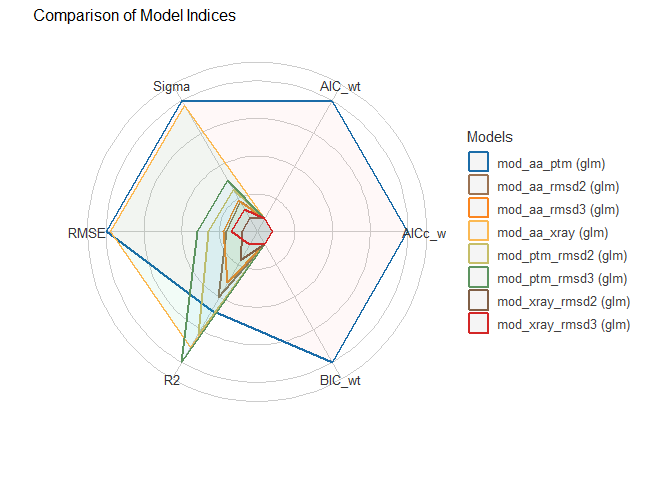

```r
compare_performance(mod_aa_xray, mod_aa_rmsd2, mod_aa_rmsd3,
                    mod_ptm_rmsd2, mod_ptm_rmsd3, mod_aa_ptm,
                    mod_xray_rmsd2, mod_xray_rmsd3) %>% plot()
```

### Finding the Best RMSD Models

```r
mod_all_rmsd2 <- glm(dat = protein_df,
               formula = RMSD_2 ~ Number_of_AA * highest_pTM)
step_rmsd2 = stepAIC(mod_all_rmsd2)
step_rmsd2$formula
```

Best Model for RMSD When Aligned with AlphaFold 2: RMSD_2 ~ Number_of_AA + highest_pTM

```r
mod_all_rmsd3 <- glm(dat = protein_df,
                     formula = RMSD_3 ~ Number_of_AA * highest_pTM)
step_rmsd3 = stepAIC(mod_all_rmsd3)
step_rmsd3$formula
```

Best Model for RMSD When Aligned with AlphaFold 3: RMSD_3 ~ Number_of_AA * highest_pTM

### Comparison of Linear Models With Best Models

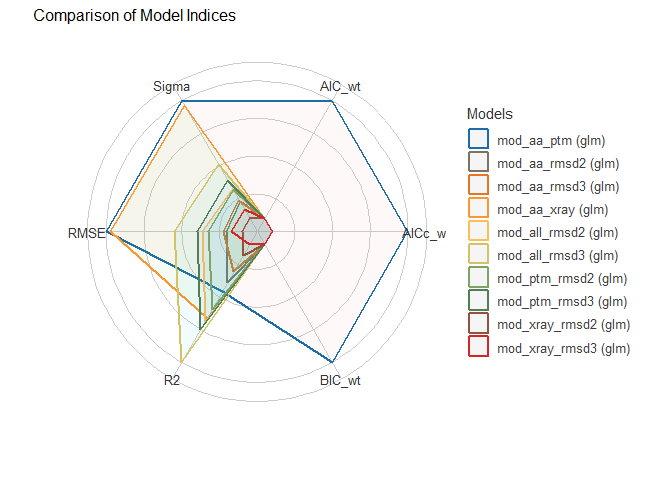

```r
compare_performance(mod_aa_xray, mod_aa_rmsd2, mod_aa_rmsd3,
                    mod_ptm_rmsd2, mod_ptm_rmsd3, mod_aa_ptm,
                    mod_xray_rmsd2, mod_xray_rmsd3,
                    mod_all_rmsd2, mod_all_rmsd3) %>% plot()
```

## Average RMSD & pTM per Method

I also thought it would be interesting to look at the average values for the outputs that indicated structural accuracy/quality (RMSD and pTM) and separate them by method.

### RMSD from Alignment with AlphaFold 2

```r
Average_RMSD_2 <- protein_df %>%
  filter(!is.na(RMSD_2)) %>%
  group_by(Method) %>%
  summarize(Mean_RMSD_AlphaFold2 = mean(RMSD_2))
Average_RMSD_2
```

[output not shown]

### RMSD from Alignment with AlphaFold 3

```r
Average_RMSD_3 <- protein_df %>%
  filter(!is.na(RMSD_3)) %>%
  group_by(Method) %>%
  summarize(Mean_RMSD_AlphaFold3 = mean(RMSD_3))
Average_RMSD_3
```

```
## # A tibble: 2 × 2
##   Method            Mean_RMSD_AlphaFold3
##   <chr>                            <dbl>
## 1 AlphaFold2                        5.11
## 2 X-Ray Diffraction                 5.56
```

| Method | Mean RMSD w/AlphaFold 3 |
| --- | --- |
| X-Ray Diffraction | 5.56075 |
| AlphaFold 2 | 5.10530 |

### pTM from Highest Rank Structure

```r
Average_pTM <- protein_df %>%
  filter(!is.na(highest_pTM)) %>%
  group_by(Method) %>%
  summarize(Mean_pTM = mean(highest_pTM))
Average_pTM
```

| Method | Mean pTM of Highest Rank |
| --- | --- |
| AlphaFold 2 | 0.789 |
| AlphaFold 3 | 0.767 |

# Conclusion

# Sources

[Li & Buck, 2021](https://pmc.ncbi.nlm.nih.gov/articles/PMC7980527/) | [RSCB Protein Data Bank](https://www.rcsb.org/) | PyMOL | [AlphaFold 2](https://colab.research.google.com/github/sokrypton/ColabFold/blob/main/AlphaFold2.ipynb#scrollTo=kOblAo-xetgx) | [AlphaFold 3](https://alphafoldserver.com/) | Protein Structural Comparison Dataset